# Supplementary Report for the article *Functional diversity can facilitate the collapse of an undesirable ecosystem state*

## 9.6 Increasing tolerance vs. increasing diversity in CB-SB-PB

At high levels of diversity vs. tolerance, resilience of the oxic state is greater when in each of the three functional groups only the most tolerant strain is present rather than when there is variation in strain tolerance within groups. It is not entirely clear why this effect occurs only in this combination.

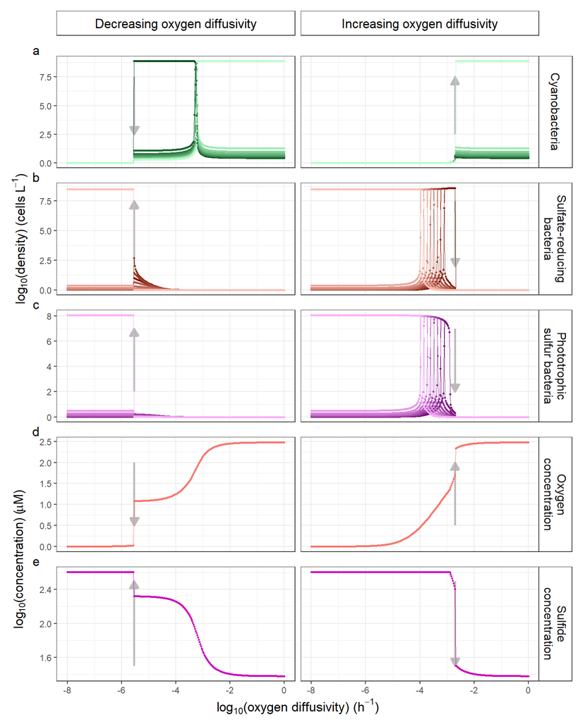

Figure 9.7: Stable states found with nine strains of CB-SB-PB and high diversity. All other aspects are the same as in Figure 4.1.

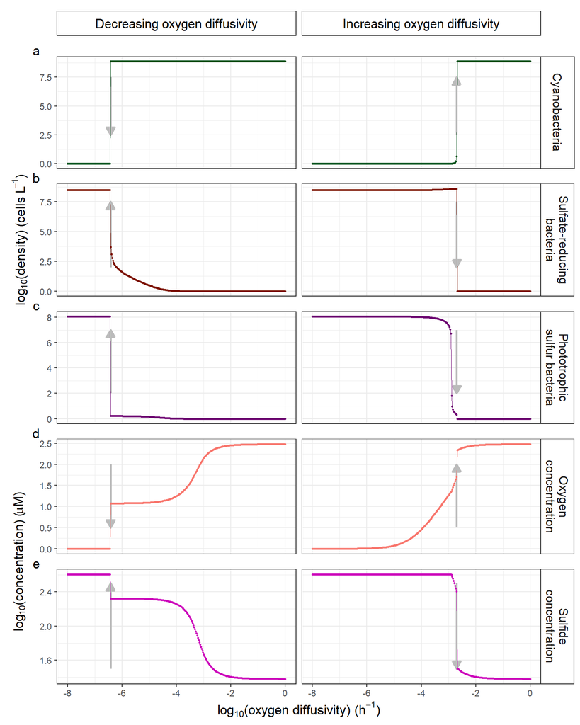

Figure 9.8: Stable states found with the single most tolerant CB strain, SB strain, and PB strain, with trait values corresponding with the diversity level in the previous figure. All other aspects are the same as in Figure 4.1.

# 10 Finding the separatrix

In the original publication ([Bush et al 2017](https://www.nature.com/articles/s41467-017-00912-x)) Figure 3a shows a separatrix in the cyanobacteria abundance - oxygen diffusivity dimensions of the system. If the system has initial cyanobacterial abundance greater than the value at the separatrix then the cyanobacterial abundance increases, and the system goes to the oxic stable state. Conversely, if the system has initial cyanobacterial abundance lower than the value at the separatrix then the cyanobacterial abundance decreases, and the system goes to the anoxic stable state.

It is critical to note, however, that the position of the separatrix depends on both the parameters of the system, and the initial conditions of variables other than cyanobacterial abundance. If the system were started with higher initial concentration, then the position of the separatrix would change (as would the values of oxygen diffusivity at which the system tipped from anoxic to oxic, and from oxic to anoxic).

This issue of dependence of the position of the separatrix on the value of initial condition of multiple state variables has particular significance when there are multiple strains per functional group. Then one cannot just vary initial total cyanobacterial abundance (as was done to create the separatrix on Figure 3a in the original publication) but one must also define how the initial abundance of each of the strains varies. One might choose to make each strain have equal initial abundance, and to vary the total (as we did in our implementation of the replication method in the main article).

We could, however, and arguably should, give the most tolerant strain of cyanobacteria higher initial relative abundance when total initial cyanobacterial abundance was low, and the least tolerant strain higher initial relative abundance when total cyanobacterial abundance was high. And we would need to specify the total and relative abundance of all cyanobacteria (and sulfur bactria) strains. Thus, with a system as complex as the 9 strain system, which has 31 state variables the separatrix is very high dimensional, and evaluating (and plotting) it in one dimension requires many assumptions. We chose to not attempt to find a meaningful set of assumptions in this study, though not because we think it would be unprofitable to do so, but rather because we did not want to risk distracting attention from findings we consider to be significant enough in their own right.

# 11 (Non-)additivity

We investigated if the effects of trait variation of individual functional groups were additive. We compared the tipping point positions as determined by our simulations with the expected position of the respective tipping point if effects of diversity in different functional groups were additive. The expected tipping point was calculated by adding the effect sizes (i.e. the difference in tipping point position between the no-diversity scenario and a given amount of trait variation) on a linear scale.

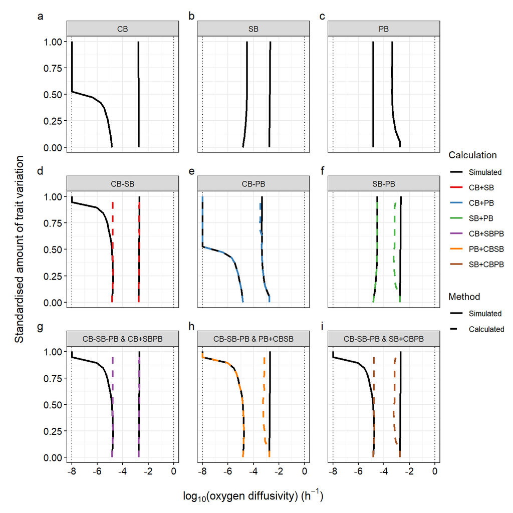

Figure 11.1: Assessing the additivity or non-additivity of the effects of trait variation. Solid black lines depict the position of the two tipping points at different levels of trait variation, as simulated with the model. The colored, dashed lines show the expected position of tipping points if effects of diversity in different functional groups were additive. The expected tipping point was calculated by adding the effect sizes of trait variation of different functional groups on a linear scale. For example, in (d) the effect size of variation in only CB was added to the effect size of variation in only SB. In (g), the effect size of variation in only CB was added to the effect size of simultaneous variation in both SB and PB. (CB: cyanobacteria, SB: sulfate-reducing bacteria, PB: phototrophic sulfur bacteria). The dotted vertical lines at -8 and 0 on the x-axis show the extent of the oxygen diffusivity gradient investigated in the simulations.

When two functional groups varied in traits, the effects of trait variation were additive when one of the groups had no diversity effect on a tipping point but non-additive when both groups had diversity effects on a tipping point (Fig. 11.1 a-f). High trait variation in cyanobacteria and sulfate-reducing bacteria caused the oxic-anoxic tipping point to occur at lower oxygen diffusivity than expected assuming additivity of the individual effects of diversity in these two groups (Fig. 11.1d). When the two groups of sulfur bacteria varied in traits, the anoxic-oxic tipping point occurred at higher oxygen diffusivity than expected by additivity (Fig. 11.1f).

# 12 Comparing the effects of different treatments

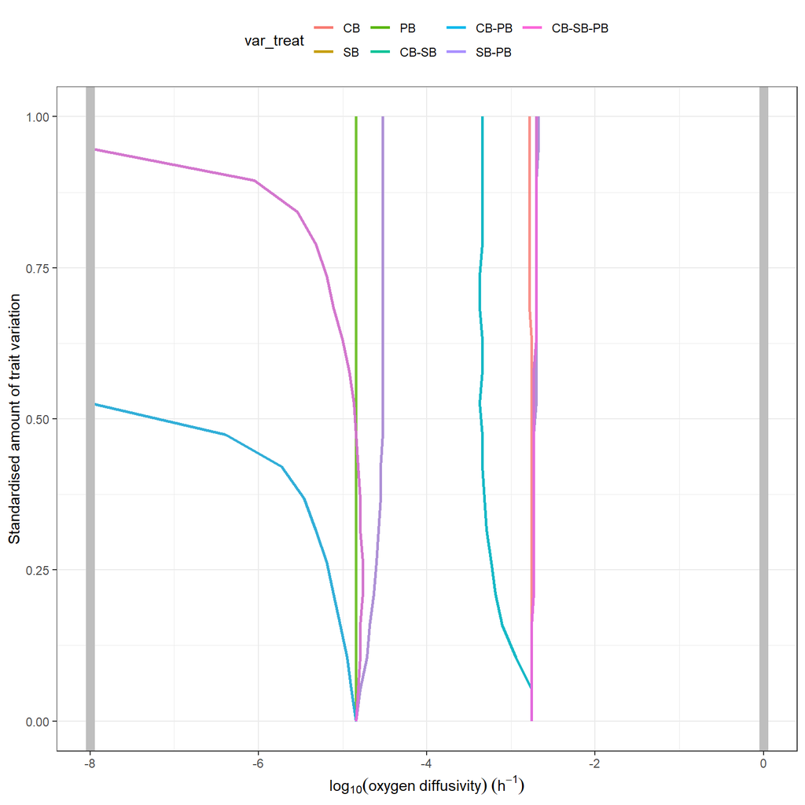

Figure 12.1: Another method for comparing the effects of different diversity treatments. Some lines (treatment combinations) are over-plotted and therefore show identical effects of some combinations.

# 13 CB diversity effects

Increased CB diversity causes a slight decrease in the resilience of the anoxic state. The following two figures show the state responses to oxygen diffusivity with low Figure 13.1 and high Figure 13.2 levels of CB diversity.

The difference in the position of the anoxic to oxic tipping point is small. It is, in fact the smallest it could be, as it is the smallest step size in oxygen diffusivity used in the simulations. Furthermore, we think the presence of higher strain diversity can increase the rate of response of the system (since there is a strain with higher growth rate than in low diversity levels) and that this difference in response rates is likely responsible for the very small difference in resilience.

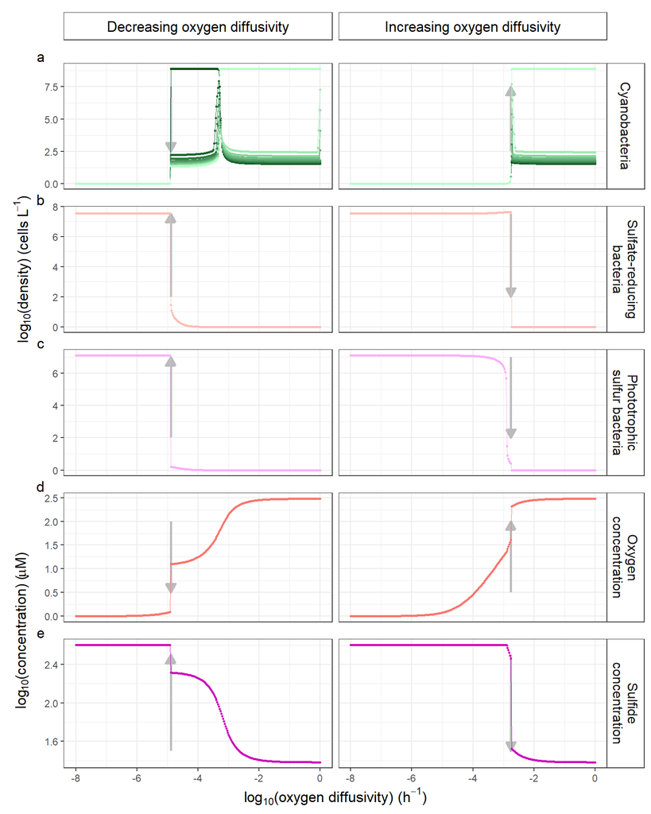

Figure 13.1: Stable state of the system with **low** level of diversity in only CB, and no diversity in the other two groups. All other aspects are as in Figure 5.6.

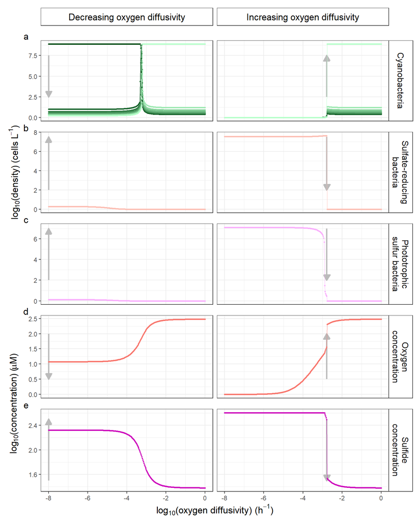

Figure 13.2: Stable state of the system with **high** level of diversity in only CB, and no diversity in the other two groups. All other aspects are as in Figure 5.6.

# 14 References

Bush, T., Diao, M., Allen, R.J., Sinnige, R., Muyzer, G. & Huisman, J. (2017). Oxic-anoxic regime shifts mediated by feedbacks between biogeochemical processes and microbial community dynamics. Nat. Commun., 8, 789.

Cardinale, B.J., Duffy, J.E., Gonzalez, A., Hooper, D.U., Perrings, C., Venail, P., et al. (2012). Biodiversity loss and its impact on humanity. Nature, 486, 59–67.

Cardinale, B.J., Matulich, K.L., Hooper, D.U., Byrnes, J.E., Duffy, E., Gamfeldt, L., et al. (2011). The functional role of producer diversity in ecosystems. Am. J. Bot., 98, 572–592.

Cardinale, B.J., Srivastava, D.S., Emmett Duffy, J., Wright, J.P., Downing, A.L., Sankaran, M., et al. (2006). Effects of biodiversity on the functioning of trophic groups and ecosystems. Nature, 443, 989–992.

Fargione, J., Tilman, D., Dybzinski, R., Lambers, J.H.R., Clark, C., Harpole, W.S., et al. (2007). From selection to complementarity: shifts in the causes of biodiversity–productivity relationships in a long-term biodiversity experiment. Proc. R. Soc. B Biol. Sci., 274, 871–876.

Hughes, A.R. & Stachowicz, J.J. (2011). Seagrass genotypic diversity increases disturbance response via complementarity and dominance. J. Ecol., 99, 445–453.

Loreau, M., Barbier, M., Filotas, E., Gravel, D., Isbell, F., Miller, S.J., et al. (2021). Biodiversity as insurance: from concept to measurement and application. Biol. Rev., 96, 2333–2354.

Loreau, M. & Hector, A. (2001). Partitioning selection and complementarity in biodiversity experiments. Nature, 412, 72–76.

Loreau, M. & Mazancourt, C. de. (2013). Biodiversity and ecosystem stability: a synthesis of underlying mechanisms. Ecol. Lett., 16, 106–115.

Luther, G.W., Findlay, A., MacDonald, D., Owings, S., Hanson, T., Beinart, R., et al. (2011). Thermodynamics and kinetics of sulfide oxidation by oxygen: a look at inorganically controlled reactions and biologically mediated processes in the environment. Front. Microbiol., 2, 62.

Steiner, C.F., Long, Z.T., Krumins, J.A. & Morin, P.J. (2006). Population and Community Resilience in Multitrophic Communities. Ecology, 87, 996–1007.